# Tugas Praktikum 5 MPDW

Robertus Mozart Sinaga - G1401231032

2025-10-02

# Library

```r
library(ggplot2)
library(tsibble)
library(tseries)
library(MASS)
library(readr)
library(forecast)
```

# Data

```r
weather <- read.csv("C:/Users/Robert/Downloads/cleaned_weather.csv")
```

### Ambil 100 Data

```r
data <- weather[401:500, c("date","VPdef")]
data
```

```
##               date VPdef
## 401 1/3/2020 18:50  1.89
## 402 1/3/2020 19:00  1.98
## 403 1/3/2020 19:10  2.04
## 404 1/3/2020 19:20  2.03
## 405 1/3/2020 19:30  1.97
## 406 1/3/2020 19:40  2.05
## 407 1/3/2020 19:50  2.06
## 408 1/3/2020 20:00  2.11
## 409 1/3/2020 20:10  2.19
## 410 1/3/2020 20:20  2.19
## 411 1/3/2020 20:30  2.17
## 412 1/3/2020 20:40  2.18
## 413 1/3/2020 20:50  2.17
## 414 1/3/2020 21:00  2.25
```

[output cut: 86 more lines]

```r
data$VPdef <- as.numeric(data$VPdef)
data$VPdef
```

```
##   [1] 1.89 1.98 2.04 2.03 1.97 2.05 2.06 2.11 2.19 2.19 2.17 2.18 2.17 2.25 2.22
##  [16] 2.21 2.17 2.11 2.08 2.14 2.07 1.73 1.54 1.53 1.59 1.70 1.77 1.71 1.37 1.12
##  [31] 1.09 1.22 1.43 1.37 1.29 1.32 1.38 1.41 1.48 1.42 1.30 1.26 1.33 1.41 1.43
##  [46] 1.44 1.61 1.57 1.35 1.25 1.25 1.20 1.21 1.27 1.38 1.46 1.50 1.54 1.58 1.57
##  [61] 1.57 1.58 1.61 1.64 1.66 1.67 1.67 1.67 1.64 1.56 1.52 1.51 1.54 1.52 1.58
##  [76] 1.61 1.60 1.60 1.63 1.67 1.71 1.77 1.80 1.84 1.84 1.82 1.85 1.91 1.96 1.97
##  [91] 2.03 2.07 2.13 2.19 2.20 2.22 2.13 2.08 2.06 2.02
```

### Data Time Series

```r
data_ts <- ts(data$VPdef)
data_ts
```

```
## Time Series:
## Start = 1
## End = 100
## Frequency = 1
##   [1] 1.89 1.98 2.04 2.03 1.97 2.05 2.06 2.11 2.19 2.19 2.17 2.18 2.17 2.25 2.22
##  [16] 2.21 2.17 2.11 2.08 2.14 2.07 1.73 1.54 1.53 1.59 1.70 1.77 1.71 1.37 1.12
##  [31] 1.09 1.22 1.43 1.37 1.29 1.32 1.38 1.41 1.48 1.42 1.30 1.26 1.33 1.41 1.43
##  [46] 1.44 1.61 1.57 1.35 1.25 1.25 1.20 1.21 1.27 1.38 1.46 1.50 1.54 1.58 1.57
##  [61] 1.57 1.58 1.61 1.64 1.66 1.67 1.67 1.67 1.64 1.56 1.52 1.51 1.54 1.52 1.58
##  [76] 1.61 1.60 1.60 1.63 1.67 1.71 1.77 1.80 1.84 1.84 1.82 1.85 1.91 1.96 1.97
##  [91] 2.03 2.07 2.13 2.19 2.20 2.22 2.13 2.08 2.06 2.02
```

## Plot Data

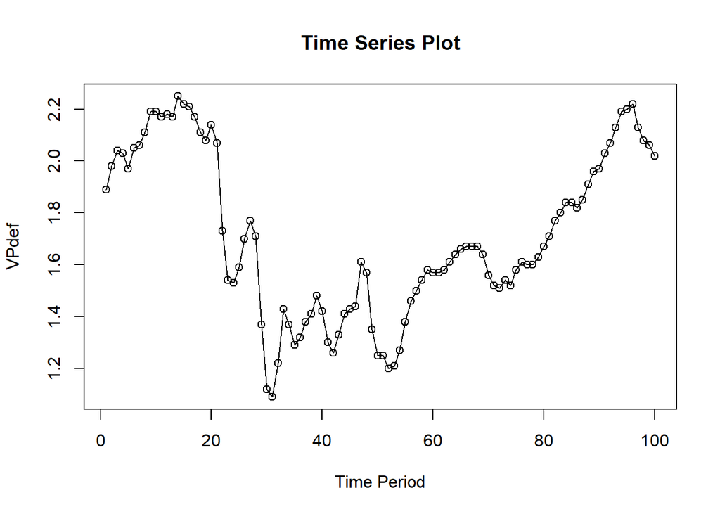

```r
ts.plot(data_ts, xlab="Time Period", ylab="VPdef",
        main = "Time Series Plot")
points(data_ts)
```

## Stasioneritas

```r
mean(data_ts)
```

```
## [1] 1.7131
```

```r
var(data_ts)
```

```
## [1] 0.1016681
```

## Plot ACF

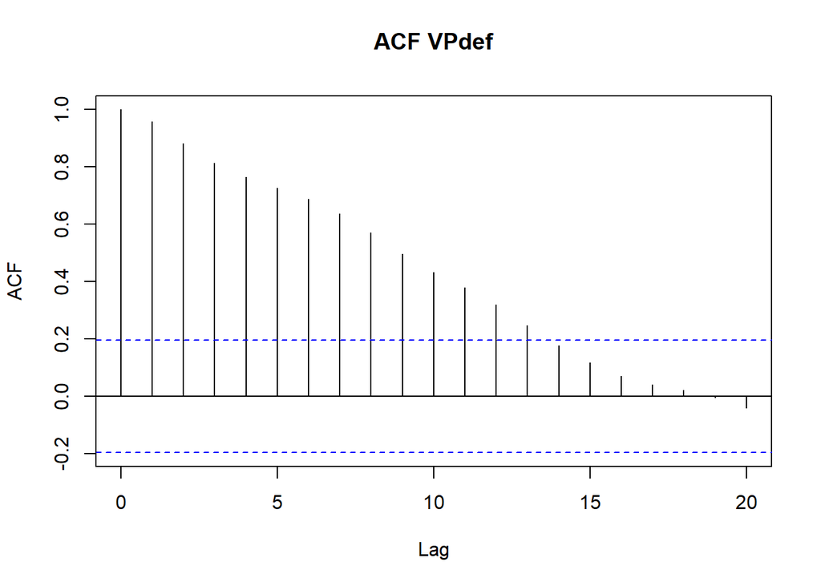

```r
acf(data_ts, main="ACF VPdef")
```

## Uji ADF

```r
adf.test(data_ts)
```

```
##
##  Augmented Dickey-Fuller Test
##
## data:  data_ts
## Dickey-Fuller = -1.0266, Lag order = 4, p-value = 0.9301
## alternative hypothesis: stationary
```

$H_0$ : Data tidak stasioner dalam rataan $H_1$ : Data stasioner dalam rataan

Hasil uji ADF menunjukkan p-value 0.9301 > 0.05, sehingga gagal menolak $H_0$ yang bearti data tidak stasioner dalam rataan.

## Plot Box-Cox

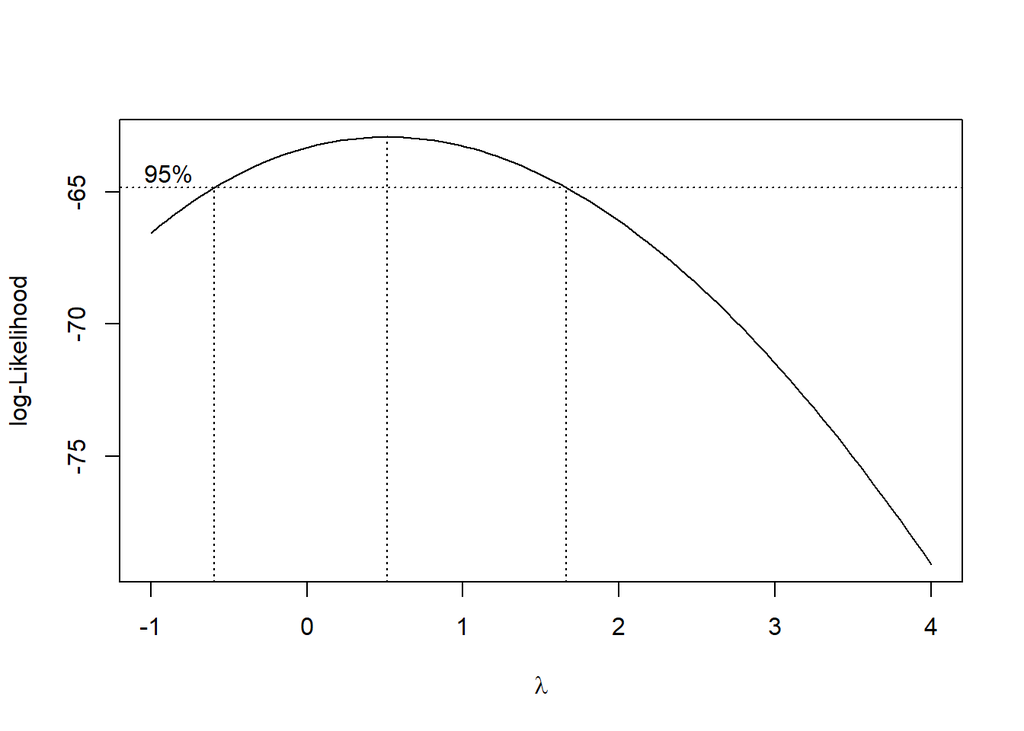

```r
index = seq(401:500)
b = boxcox(data_ts~index, lambda = seq(-1,4,by=1))
```

### Nilai Rounded Lambda

```r
lambda = b$x[which.max(b$y)]
lambda
```

```
## [1] 0.5151515
```

### SK

```r
b$x[b$y > max(b$y) - 1/2 * qchisq(.95,1)]
```

```
##  [1] -0.54545455 -0.49494949 -0.44444444 -0.39393939 -0.34343434 -0.29292929
##  [7] -0.24242424 -0.19191919 -0.14141414 -0.09090909 -0.04040404  0.01010101
## [13]  0.06060606  0.11111111  0.16161616  0.21212121  0.26262626  0.31313131
## [19]  0.36363636  0.41414141  0.46464646  0.51515152  0.56565657  0.61616162
## [25]  0.66666667  0.71717172  0.76767677  0.81818182  0.86868687  0.91919192
## [31]  0.96969697  1.02020202  1.07070707  1.12121212  1.17171717  1.22222222
## [37]  1.27272727  1.32323232  1.37373737  1.42424242  1.47474747  1.52525253
## [43]  1.57575758  1.62626263
```

Hasil plot Box-Cox menunjukkan nilai *rounded value* ($\lambda$) optimum sebesar 0.515 dan pada selang kepercayaan 95% memiliki batas bawah -0.545 dan batas atas 1.626. Selang tersebut memuat nilai 1 sehingga transformasi tidak wajib dilakukan, namun dapat dicoba untuk meningkatkan stasioneritas data.

# Partisi Data

## Data Training

```r
data_ts1 <- data_ts[1:80] |> ts()
mean(data_ts1)
```

```
## [1] 1.646375
```

```r
var(data_ts1)
```

```
## [1] 0.09903859
```

### Plot Time Series Data Training

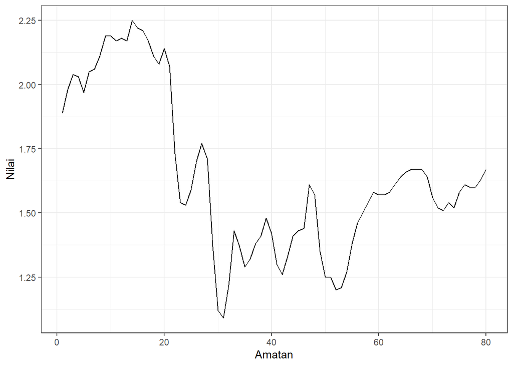

```r
data_ts1 |> as_tsibble() |>
  ggplot(aes(x = index, y = value)) +
  geom_line()+theme_bw() +
  xlab("Amatan") + ylab("Nilai")
```

### Plot ACF Data Training

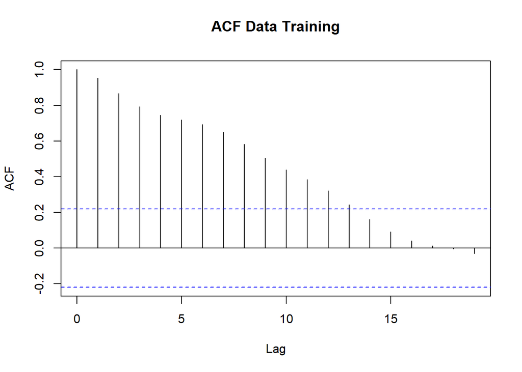

```r
acf(data_ts1, main="ACF Data Training")
```

### Uji ADF Data Training

```r
adf.test(data_ts1)
```

```
##
##  Augmented Dickey-Fuller Test
##
## data:  data_ts1
## Dickey-Fuller = -1.0505, Lag order = 4, p-value = 0.9245
## alternative hypothesis: stationary
```

$H_0$ : Data tidak stasioner dalam rataan $H_1$ : Data stasioner dalam rataan

Hasil uji ADF menunjukkan p-value 0.9245 > 0.05, sehingga gagal menolak $H_0$ yang bearti data tidak stasioner dalam rataan.

### Plot Box-Cox Data Training

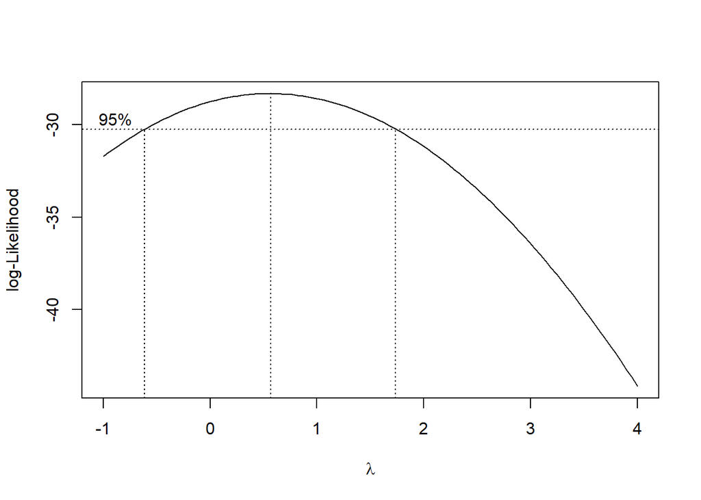

```r
index1 = seq(1:80)
b1 = boxcox(data_ts1~index1, lambda = seq(-1,4,by=1))
```

#### Nilai Rounded Lambda

```r
lambda1 = b1$x[which.max(b1$y)]
lambda1
```

```
## [1] 0.5656566
```

#### SK

```r
b1$x[b1$y > max(b1$y) - 1/2 * qchisq(.95,1)]
```

```
##  [1] -0.59595960 -0.54545455 -0.49494949 -0.44444444 -0.39393939 -0.34343434
##  [7] -0.29292929 -0.24242424 -0.19191919 -0.14141414 -0.09090909 -0.04040404
## [13]  0.01010101  0.06060606  0.11111111  0.16161616  0.21212121  0.26262626
## [19]  0.31313131  0.36363636  0.41414141  0.46464646  0.51515152  0.56565657
## [25]  0.61616162  0.66666667  0.71717172  0.76767677  0.81818182  0.86868687
## [31]  0.91919192  0.96969697  1.02020202  1.07070707  1.12121212  1.17171717
## [37]  1.22222222  1.27272727  1.32323232  1.37373737  1.42424242  1.47474747
## [43]  1.52525253  1.57575758  1.62626263  1.67676768  1.72727273
```

Hasil plot Box-Cox menunjukkan nilai *rounded value* ($\lambda$) optimum sebesar 0.5656 dan pada selang kepercayaan 95% memiliki batas bawah -0.5959 dan batas atas 1.727. Selang tersebut memuat nilai 1.

## Data Testing

```r
data_ts2 <- data_ts[81:100] |> ts()
mean(data_ts2)
```

```
## [1] 1.98
```

```r
var(data_ts2)
```

```
## [1] 0.02422105
```

### Plot Time Series Data Testing

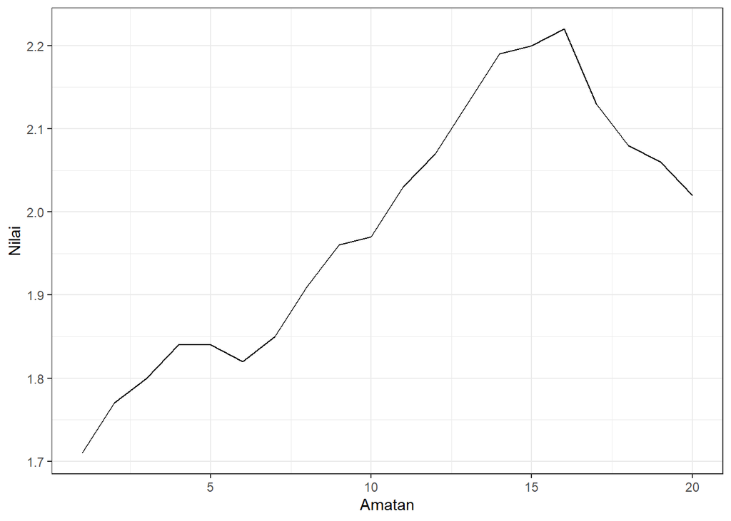

```r
data_ts2 |> as_tsibble() |>
  ggplot(aes(x = index, y = value)) +
  geom_line()+theme_bw() +
  xlab("Amatan") + ylab("Nilai")
```

### Plot ACF Data Testing

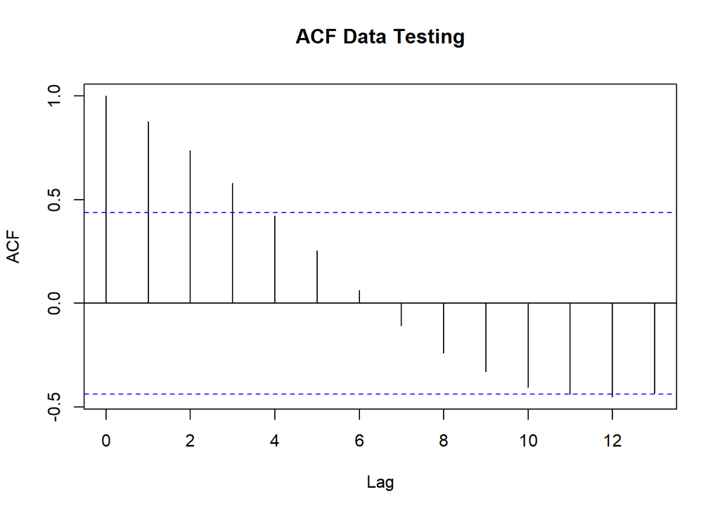

```r
acf(data_ts2, main="ACF Data Testing")
```

### Uji ADF Data Testing

```r
adf.test(data_ts2)
```

```
##
##  Augmented Dickey-Fuller Test
##
## data:  data_ts2
## Dickey-Fuller = -1.145, Lag order = 2, p-value = 0.8981
## alternative hypothesis: stationary
```

$H_0$ : Data tidak stasioner dalam rataan $H_1$ : Data stasioner dalam rataan

Hasil uji ADF menunjukkan p-value 0.8981 > 0.05, sehingga gagal menolak $H_0$ yang bearti data tidak stasioner dalam rataan.

### Plot Box-Cox Data Testing

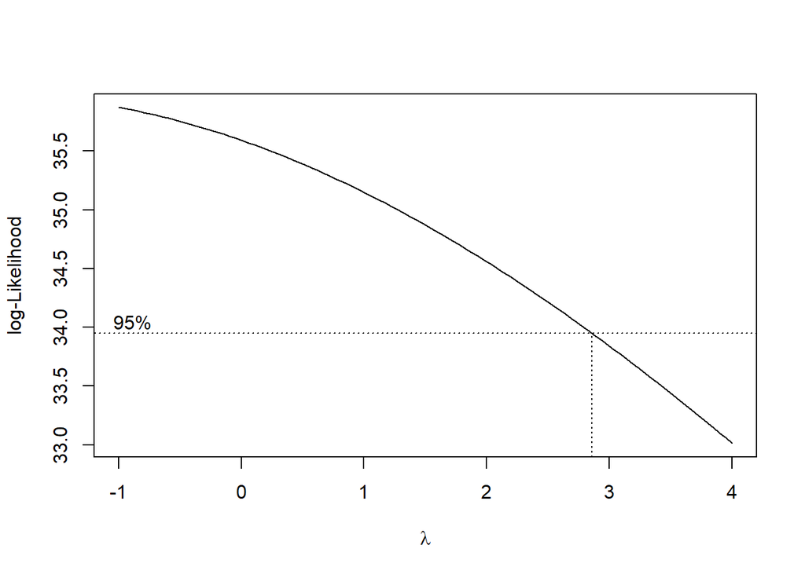

```r
index2 = seq(81:100)
b2 = boxcox(data_ts2~index2, lambda = seq(-1,4,by=1))
```

#### Nilai Rounded Lambda

```r
lambda2 = b2$x[which.max(b2$y)]
lambda2
```

```
## [1] -1
```

#### SK

```r
b2$x[b2$y > max(b2$y) - 1/2 * qchisq(.95,1)]
```

```
##  [1] -1.00000000 -0.94949495 -0.89898990 -0.84848485 -0.79797980 -0.74747475
##  [7] -0.69696970 -0.64646465 -0.59595960 -0.54545455 -0.49494949 -0.44444444
## [13] -0.39393939 -0.34343434 -0.29292929 -0.24242424 -0.19191919 -0.14141414
## [19] -0.09090909 -0.04040404  0.01010101  0.06060606  0.11111111  0.16161616
## [25]  0.21212121  0.26262626  0.31313131  0.36363636  0.41414141  0.46464646
## [31]  0.51515152  0.56565657  0.61616162  0.66666667  0.71717172  0.76767677
## [37]  0.81818182  0.86868687  0.91919192  0.96969697  1.02020202  1.07070707
## [43]  1.12121212  1.17171717  1.22222222  1.27272727  1.32323232  1.37373737
## [49]  1.42424242  1.47474747  1.52525253  1.57575758  1.62626263  1.67676768
## [55]  1.72727273  1.77777778  1.82828283  1.87878788  1.92929293  1.97979798
## [61]  2.03030303  2.08080808  2.13131313  2.18181818  2.23232323  2.28282828
## [67]  2.33333333  2.38383838  2.43434343  2.48484848  2.53535354  2.58585859
## [73]  2.63636364  2.68686869  2.73737374  2.78787879  2.83838384
```

Hasil plot Box-Cox menunjukkan nilai *rounded value* ($\lambda$) optimum sebesar -1 dan pada selang kepercayaan 95% memiliki batas bawah -1 dan batas atas 2.838. Selang tersebut memuat nilai 1.

# Penanganan

## Transformasi Box-Cox

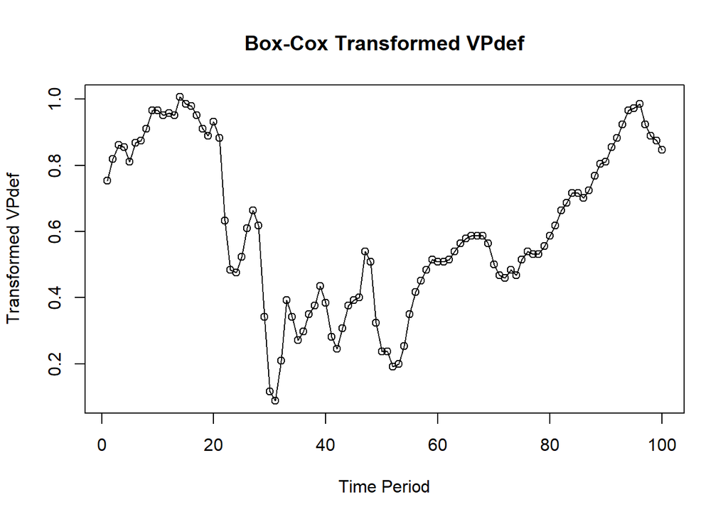

```r
# Transformasi Box-Cox dengan Lambda = 0.515
data_bc <- BoxCox(data_ts, lambda = 0.515)

# Plot Hasil Transformasi
ts.plot(data_bc, xlab = "Time Period", ylab = "Transformed VPdef",
        main = "Box-Cox Transformed VPdef")
points(data_bc)
```

### Plot Sesudah Transformasi Box-Cox

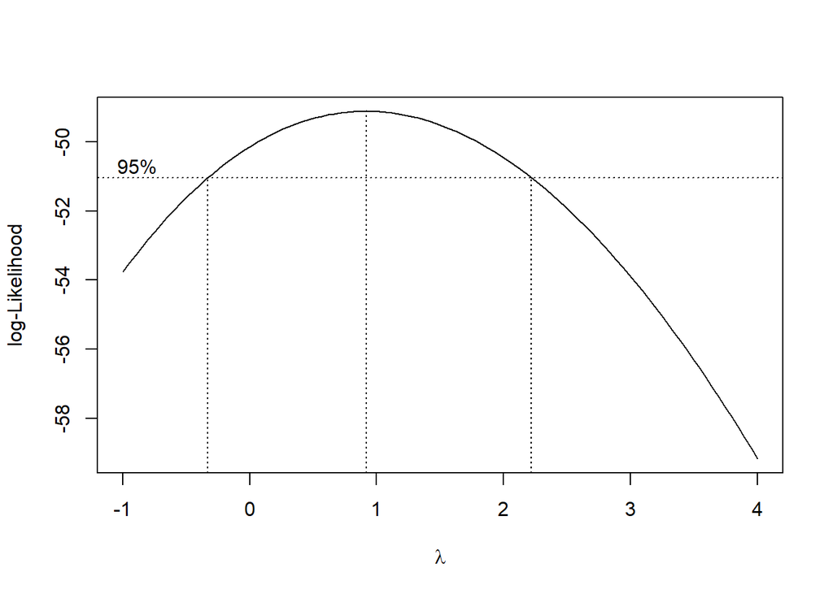

```r
# Index waktu
index <- seq_along(data_bc)

# tambah konstanta agar semua nilai positif
data_bc_shifted <- data_bc - min(data_bc) + 1

# model Regresi Dummy
model_bc <- lm(data_bc_shifted ~ index)

# plot Box-Cox
b <- boxcox(model_bc, lambda = seq(-1, 4, by = 0.1))
```

#### Nilai Lambda Optimum

```r
lambda_bc <- b$x[which.max(b$y)]
lambda_bc
```

```
## [1] 0.9191919
```

#### SK

```r
b$x[b$y > max(b$y) - 1/2 * qchisq(.95,1)]
```

```
##  [1] -0.29292929 -0.24242424 -0.19191919 -0.14141414 -0.09090909 -0.04040404
##  [7]  0.01010101  0.06060606  0.11111111  0.16161616  0.21212121  0.26262626
## [13]  0.31313131  0.36363636  0.41414141  0.46464646  0.51515152  0.56565657
## [19]  0.61616162  0.66666667  0.71717172  0.76767677  0.81818182  0.86868687
## [25]  0.91919192  0.96969697  1.02020202  1.07070707  1.12121212  1.17171717
## [31]  1.22222222  1.27272727  1.32323232  1.37373737  1.42424242  1.47474747
## [37]  1.52525253  1.57575758  1.62626263  1.67676768  1.72727273  1.77777778
## [43]  1.82828283  1.87878788  1.92929293  1.97979798  2.03030303  2.08080808
## [49]  2.13131313  2.18181818
```

Hasil plot Box-Cox menunjukkan nilai *rounded value* ($\lambda$) optimum sebesar 0.919 dan pada selang kepercayaan 95% memiliki batas bawah -0.29 dan batas atas 2.18. Selang tersebut memuat nilai 1 sehingga hasil transformasi Box-Cox tetap stasioner dalam ragam.